# Practical Machine Learning Course Project

Niccolò Rocco

May 5, 2019

## Data set creation

```r
data<-read.csv("pml-training.csv")
count_na_blank<-vector(length=dim(data)[2])
for (i in 1:dim(data)[2] ){
 count_na_blank[i]<-length((which  ( is.na(data[,i]) | data[,i]==""    )))
}
#I observe that many columns have 19216 Nas or blannk values. I remove these and the first 7 columns
count_na_blank[1:7]<-1
new_data<-data[,which(count_na_blank==0)]
```

## Training and Test samples

I load the caret package and I build the training and the test sets, with the createDataPartition function having p=0.7.

```r
library(caret)
set.seed(3456)
inTrain<-createDataPartition(y=new_data$classe,p=0.7,list=FALSE)
training<-new_data[inTrain,]
testing<-new_data[-inTrain,]
```

## Fitting

I have to predict a qualitative variable, that is the “classe”. So, I believe that a good choice is predicting with trees. I tried a general recursive partitioning, method *rpart*, but the accuracy was bad (between 0.5 and 0.6). So, I fit a Random Forest. Because of the long time requested to fit that method on my pc, I choose to do a *parallel computing*. I impose to making clusters leaving one core to the operating system, and I set the Train Control to cross validation. I have to load the libraries *parallel* and *doParallel* to do the parallel computing.

```r
x<-training[,-53]
y <- training[,53]
library(parallel)
library(doParallel)

cluster <- makeCluster(detectCores() - 1) # convention to leave 1 core for OS
registerDoParallel(cluster)

set.seed(54646)
fitControl <- trainControl(method = "cv",
                           number = 5,
                           allowParallel = TRUE)

set.seed(3112)
fit <- train(x,y, method="rf",data=new_data,trControl = fitControl)
#I stop the paralleling method
stopCluster(cluster)
registerDoSEQ()
```

## Results

I notice that the method accuracy is very high (about 0.99). From Var Importance plot, I deduce the importance variable. The first variables is roll_belt.

```
confusionMatrix.train(fit) #accuracy very
plot(varImp(fit),top=10)
p<-ggplot(training, aes(x=roll_belt, y=yaw_belt, color=classe))
p+geom_point()
```

```r
confusionMatrix.train(fit) #accuracy very high
```

```
## Cross-Validated (5 fold) Confusion Matrix
##
## (entries are percentual average cell counts across resamples)
##
##           Reference
## Prediction    A    B    C    D    E
##          A 28.4  0.1  0.0  0.0  0.0
##          B  0.0 19.2  0.2  0.0  0.0
##          C  0.0  0.1 17.3  0.4  0.0
##          D  0.0  0.0  0.0 16.0  0.1
##          E  0.0  0.0  0.0  0.0 18.3
##
##  Accuracy (average) : 0.991
```

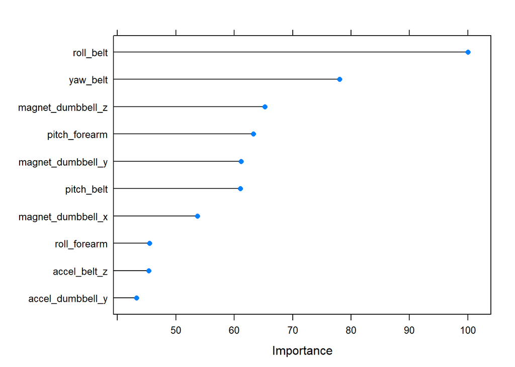

```r
plot(varImp(fit),top=10)
```

In the below figure, I plot the two most important variables, colored by the classe variable (the one to predict) and I can see specif patterns, indeed the two variables explain a good percentage of the classe variable.

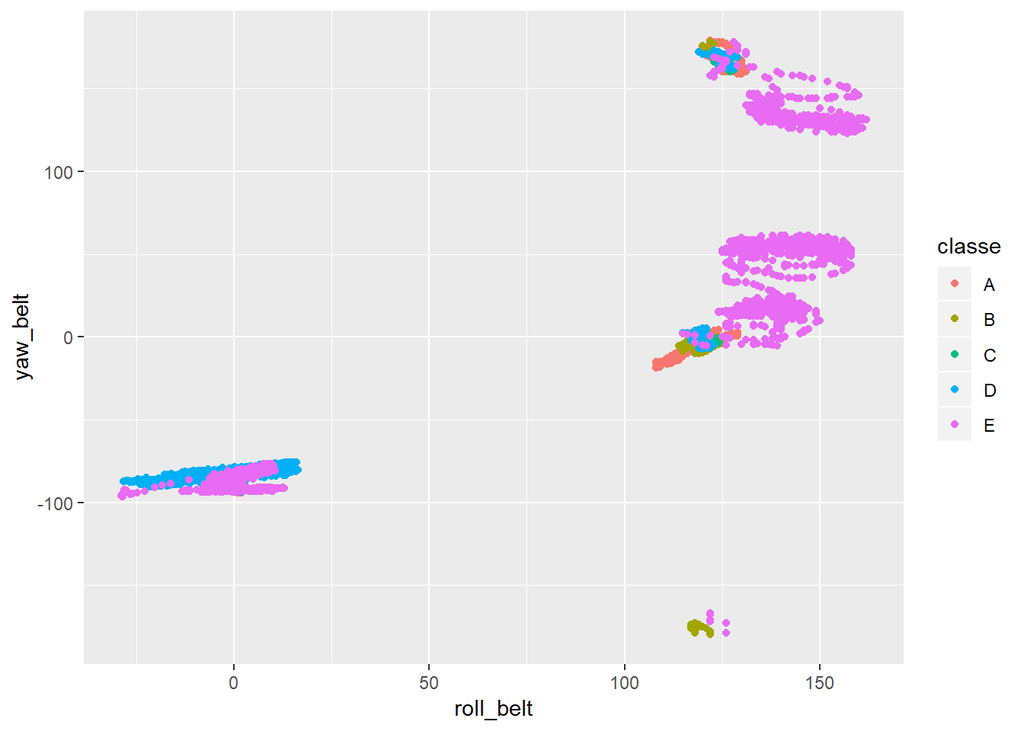

```r
p<-ggplot(training, aes(x=roll_belt, y=yaw_belt, color=classe))
p+geom_point()
```

I predict the classe variable also in the testing set and the acccuracy is high (about 0.99). Se the model is satisfying.

```r
test_prediction<-predict(fit,newdata=testing)
confusionMatrix(test_prediction , testing$classe) #accuracy very high
```

```
## Confusion Matrix and Statistics
##
##           Reference
## Prediction    A    B    C    D    E
##          A 1674    6    0    0    0
##          B    0 1133    2    0    0
##          C    0    0 1023   21    1
##          D    0    0    1  943    3
##          E    0    0    0    0 1078
##
## Overall Statistics
##
##                Accuracy : 0.9942
##                  95% CI : (0.9919, 0.996)
##     No Information Rate : 0.2845
##     P-Value [Acc > NIR] : < 2.2e-16
##
##                   Kappa : 0.9927
##
##  Mcnemar's Test P-Value : NA
##
## Statistics by Class:
##
##                      Class: A Class: B Class: C Class: D Class: E
## Sensitivity            1.0000   0.9947   0.9971   0.9782   0.9963
## Specificity            0.9986   0.9996   0.9955   0.9992   1.0000
## Pos Pred Value         0.9964   0.9982   0.9789   0.9958   1.0000
## Neg Pred Value         1.0000   0.9987   0.9994   0.9957   0.9992
## Prevalence             0.2845   0.1935   0.1743   0.1638   0.1839
## Detection Rate         0.2845   0.1925   0.1738   0.1602   0.1832
## Detection Prevalence   0.2855   0.1929   0.1776   0.1609   0.1832
## Balanced Accuracy      0.9993   0.9972   0.9963   0.9887   0.9982
```

## Prediction

I predict the classe variable for the 20 observations in the “pml-testing.csv” file. On the data set, I do the operations done upper to the training (removed NAs, blanks and first seven varaibles). Also, I do a simple trick to have the same training variables format.

```r
data_to_test<-read.csv("pml-testing.csv")
data_to_test_new<-data_to_test[,which(count_na_blank==0)]
names(data_to_test_new)[53]<-"classe"
data_to_test_new <- rbind(training[1, ] , data_to_test_new)
data_to_test_new <- data_to_test_new[-1,]
data_to_test_prediction<-predict(fit,newdata=data_to_test_new)
data_to_test_prediction
```

```
##  [1] B A B A A E D B A A B C B A E E A B B B
## Levels: A B C D E
```